# Extreme gradient boosting time series forecasting

Peter Ellis

26 November 2016

The `forecastxgb` package provides time series modelling and forecasting functions that combine the machine learning approach of Chen, He and Benesty’s [`xgboost`](https://CRAN.R-project.org/package=xgboost) with the convenient handling of time series and familiar API of Rob Hyndman’s [`forecast`](http://github.com/robjhyndman/forecast). It applies to time series the Extreme Gradient Boosting proposed in [*Greedy Function Approximation: A Gradient Boosting Machine*, by Jerome Friedman in 2001](http://www.jstor.org/stable/2699986). xgboost has become an important machine learning algorithm; nicely explained in [this accessible documentation](http://xgboost.readthedocs.io/en/latest/model.html).

**Warning: this package is under active development. The API and default settings should be expected to continue to change.**

## Basic usage

The workhorse function is `xgbar`. This fits a model to a time series. Under the hood, it creates a matrix of explanatory variables based on lagged versions of the response time series, and (optionally) dummy variables of some sort for seasons. That matrix is then fed as the feature set for `xgboost` to do its stuff.

### Univariate

Usage with default values is straightforward. Here it is fit to Australian monthly gas production 1956-1995, an example dataset provided in `forecast`:

```r
library(forecastxgb)
model <- xgbar(gas)
```

By default, `xgbar` uses row-wise cross-validation to determine the best number of rounds of iterations for the boosting algorithm without overfitting. A final model is then fit on the full available dataset. The relative importance of the various features in the model can be inspected by `importance_xgb()` or, more conveniently, the `summary` method for objects of class `xgbar`.

```r
summary(model)
```

```
Importance of features in the xgboost model:
    Feature         Gain        Cover   Frequency
 1:   lag12 5.097936e-01 0.1480752533 0.078475336
 2:   lag11 2.796867e-01 0.0731403763 0.042600897
 3:   lag13 1.043604e-01 0.0355137482 0.031390135
 4:   lag24 7.807860e-02 0.1320115774 0.069506726
 5:    lag1 1.579312e-02 0.1885383502 0.181614350
 6:   lag23 5.616290e-03 0.0471490593 0.042600897
 7:    lag9 2.510372e-03 0.0459623734 0.040358744
 8:    lag2 6.759874e-04 0.0436179450 0.053811659
 9:   lag14 5.874155e-04 0.0311432706 0.026905830
10:   lag10 5.467606e-04 0.0530535456 0.053811659
11:    lag6 3.820611e-04 0.0152243126 0.033632287
12:    lag4 2.188107e-04 0.0098697540 0.035874439
13:   lag22 2.162973e-04 0.0103617945 0.017937220
```

[output cut: 21 more lines]

We see in the case of the gas data that the most important feature in explaining gas production is the production 12 months previously; and then other features decrease in importance from there but still have an impact.

Forecasting is the main purpose of this package, and a `forecast` method is supplied. The resulting objects are of class `forecast` and familiar generic functions work with them.

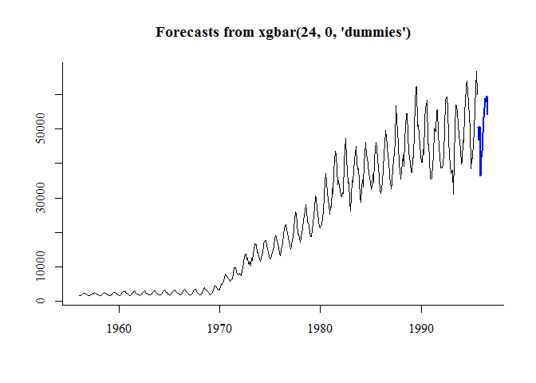

```r
fc <- forecast(model, h = 12)
plot(fc)
```

Note that prediction intervals are not currently available.

### With external regressors

External regressors can be added by using the `xreg` argument familiar from other forecast functions like `auto.arima` and `nnetar`. `xreg` can be a vector or `ts` object but is easiest to integrate into the analysis if it is a matrix (even a matrix with one column) with well-chosen column names; that way feature names persist meaningfully.

The example below, with data taken from the `fpp` package supporting Athanasopoulos and Hyndman’s [Forecasting Principles and Practice](https://www.otexts.org/fpp) book, shows income being used to explain consumption. In the same way that the response variable `y` is expanded into lagged versions of itself, each column in `xreg` is expanded into lagged versions, which are then treated as individual features for `xgboost`.

```r
library(fpp)
consumption <- usconsumption[ ,1]
income <- matrix(usconsumption[ ,2], dimnames = list(NULL, "Income"))
consumption_model <- xgbar(y = consumption, xreg = income)
summary(consumption_model)
```

```
Importance of features in the xgboost model:
        Feature        Gain       Cover   Frequency
 1:        lag2 0.253763903 0.082908446 0.124513619
 2:        lag1 0.219332682 0.114608734 0.171206226
 3: Income_lag0 0.115604367 0.183107958 0.085603113
 4:        lag3 0.064652150 0.093105742 0.089494163
 5:        lag8 0.055645114 0.099756152 0.066147860
 6: Income_lag8 0.050460959 0.049434715 0.050583658
 7: Income_lag1 0.047187235 0.088561295 0.050583658
 8: Income_lag6 0.040512834 0.029150964 0.050583658
 9:        lag6 0.031876878 0.044225227 0.054474708
10: Income_lag2 0.020355402 0.015739304 0.031128405
11: Income_lag5 0.018011250 0.036577256 0.035019455
12:        lag5 0.017930780 0.032143649 0.035019455
13:        lag7 0.016674036 0.034249612 0.027237354
14: Income_lag4 0.015952784 0.025714919 0.038910506
15: Income_lag7 0.009850701 0.021724673 0.019455253
16:        lag4 0.008819146 0.028929284 0.038910506
17: Income_lag3 0.008720737 0.013855021 0.019455253
18:     season4 0.003152234 0.001551762 0.003891051
19:     season3 0.001496807 0.004655287 0.007782101

 20 features considered.
164 original observations.
156 effective observations after creating lagged features.
```

We see that the two most important features explaining consumption are the two previous quarters’ values of consumption; followed by the income in this quarter; and so on.

The challenge of using external regressors in a forecasting environment is that to forecast, you need values of the future external regressors. One way this is sometimes done is by first forecasting the individual regressors. In the example below we do this, making sure the data structure is the same as the original `xreg`. When the new value of `xreg` is given to `forecast`, it forecasts forward the number of rows of the new `xreg`.

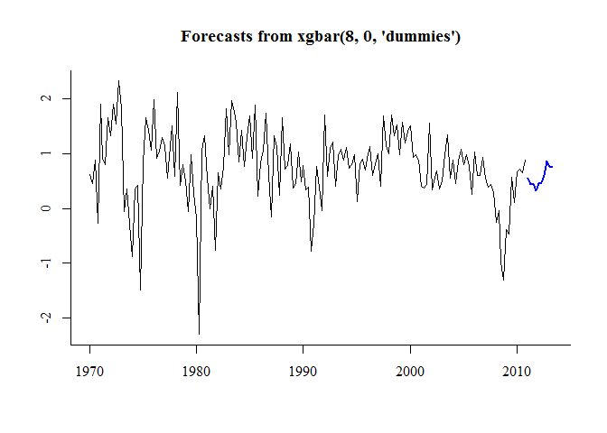

```r
income_future <- matrix(forecast(xgbar(usconsumption[,2]), h = 10)$mean,
                        dimnames = list(NULL, "Income"))
plot(forecast(consumption_model, xreg = income_future))
```

## Advanced usage

The default settings for `xgbar` give reasonable results. The key things that can be changed by the user include:

- the maximum number of lags to include as explanatory variables. There is a trade-off here, as each number higher this gets, the less rows of data you have. Generally at least two full seasonal cycles are desired, and the default is `max(8, 2 * frequency(y))`. When the data gets very short this value is sometimes forced lower, with a warning.
- the method for choosing the maximum number of boosting iterations. The default is row-wise cross validation, after the matrix of lagged explanatory variables has been created. This is not a traditional approach for cross validation of time series, because the resampling does not preserve the original ordering. However, the presence of the lagged values means this is less of an issue. The main alternative (`nrounds_method = "v"`) is to set aside the final 20% of data and use that for validation of the various numbers of rounds of iterations of the first 80% of training data. Experiments so far suggest that both methods give similar results; if anything the cross-validation method generally recommends a slightly lower number of iterations than does the alternative.

## Options

### Seasonality

Currently there are three methods of treating seasonality.

- The current default method is to throw dummy variables for each season into the mix of features for `xgboost` to work with.
- An alternative is to perform classic multiplicative seasonal adjustment on the series before feeding it to `xgboost`. This seems to work better.
- A third option is to create a set of pairs of Fourier transform variables and use them as x regressors

```
No h provided so forecasting forward 24 periods.
```

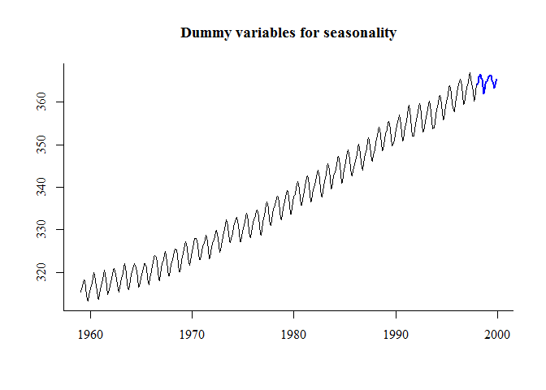

```
No h provided so forecasting forward 24 periods.
```

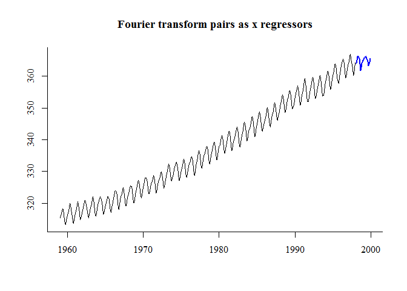

All methods perform quite poorly at the moment, suffering from the difficulty the default settings have in dealing with non-stationary data (see below).

### Transformations

The data can be transformed by a modulus power transformation (as per John and Draper, 1980) before feeding to `xgboost`. This transformation is similar to a Box-Cox transformation, but works with negative data. Leaving the `lambda` parameter as 1 will effectively switch off this transformation.

```
No h provided so forecasting forward 24 periods.
```

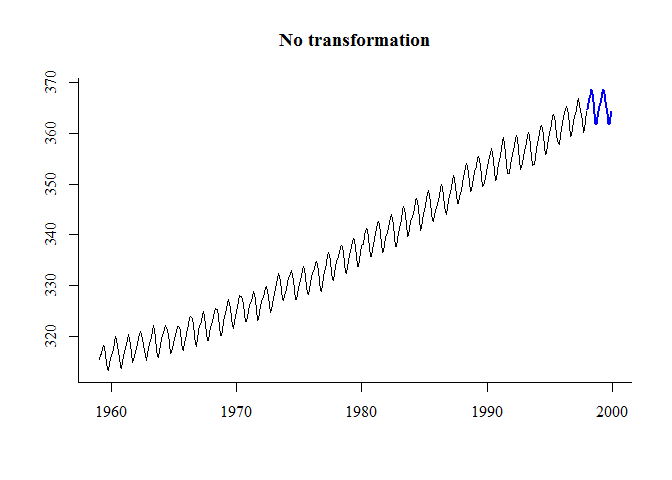

```
No h provided so forecasting forward 24 periods.
```

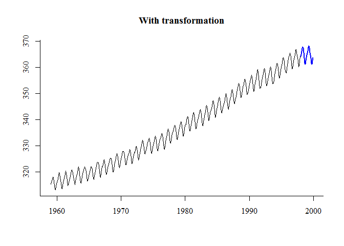

Version 0.0.9 of `forecastxgb` gave `lambda` the default value of `BoxCox.lambda(abs(y))`. This returned spectacularly bad forecasting results. Forcing this to be between 0 and 1 helped a little, but still gave very bad results. So far there isn’t evidence (but neither is there enough investigation) that a Box Cox transformation helps xgbar do its model fitting at all.

### Non-stationarity

From experiments so far, it seems the basic idea of `xgboost` struggles in this context with extrapolation into a new range of variables not in the training set. This suggests better results might be obtained by transforming the series into a stationary one before modelling - a similar approach to that taken by `forecast::auto.arima`. This option is available by `trend_method = "differencing"` and seems to perform well - certainly better than without - and it will probably be made a default setting once more experience is available.

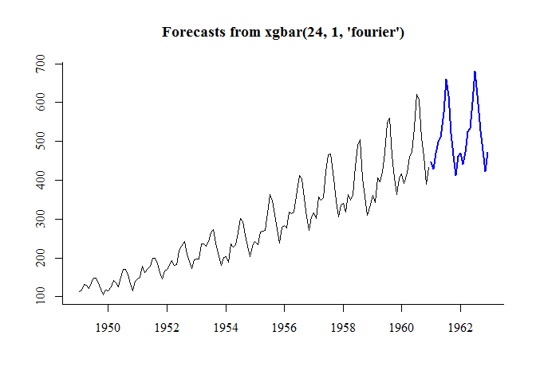

```r
model <- xgbar(AirPassengers, trend_method = "differencing", seas_method = "fourier")
plot(forecast(model, 24))
```

## Future developments

Future work might include:

- additional automated time-dependent features (eg dummy variables for trading days, Easter, etc)
- ability to include xreg values that don’t get lagged
- some kind of automated multiple variable forecasting, similar to a vector-autoregression.
- better choices of defaults for values such as `lambda` (for power transformations), `K` (for Fourier transforms) and, most likely to be effective, `maxlag`.

## Tourism forecasting competition

Here is a more substantive example. I use the 1,311 datasets from the 2010 Tourism Forecasting Competition described in in [Athanasopoulos et al (2011)](http://robjhyndman.com/papers/forecompijf.pdf), originally in the International Journal of Forecasting (2011) 27(3), 822-844. The data are available in the CRAN package Tcomp. Each data object is a list, with elements inlcuding `x` (the original training data), `h` (the forecasting period) and `xx` (the test data of length `h`). Only univariate time series are included.

To give the `xgbar` model a good test, I am going to compare its performance in forecasting the 1,311 `xx` time series from the matching `x` series with three other modelling approaches:

- Auto-regressive integrated moving average (ARIMA)
- Theta
- Neural networks

Those three are all from Rob Hyndman’s `forecast` package. I am also going to look at the performance of ensembles of the four model types. With all combinations this means 15 models in total.

Because all four models use the `forecast` paradigm it is relatively straightforward to structure the analysis. The code below is a little repetitive but should be fairly transparent. Because of the scale and the embarrassingly parallel nature of the work (ie no particular reason to do it in any particular order, so easy to split into tasks for different processes to do in parallel), I use `foreach` and `doParallel` to make the best use of my 8 logical processors. The code below sets up a cluster for the parallel computing and a function `competition` which will work on any object of class `Mcomp`, which `Tcomp` inherits from the `Mcomp` package providing the first three “M” forecasting competition data collections.

```r
#=============prep======================
library(Tcomp)
library(foreach)
library(doParallel)
library(forecastxgb)
library(dplyr)
library(ggplot2)
library(scales)
```

```r
#============set up cluster for parallel computing===========
cluster <- makeCluster(7) # only any good if you have at least 7 processors :)
registerDoParallel(cluster)

clusterEvalQ(cluster, {
  library(Tcomp)
  library(forecastxgb)
})


#===============the actual analytical function==============
competition <- function(collection, maxfors = length(collection)){
  if(class(collection) != "Mcomp"){
    stop("This function only works on objects of class Mcomp, eg from the Mcomp or Tcomp packages.")
  }
  nseries <- length(collection)
  mases <- foreach(i = 1:maxfors, .combine = "rbind") %dopar% {
    thedata <- collection[[i]]
    seas_method <- ifelse(frequency(thedata$x) < 6, "dummies", "fourier")
    mod1 <- xgbar(thedata$x, trend_method = "differencing", seas_method = seas_method, lambda = 1, K = 2)
    fc1 <- forecast(mod1, h = thedata$h)
    fc2 <- thetaf(thedata$x, h = thedata$h)
    fc3 <- forecast(auto.arima(thedata$x), h = thedata$h)
    fc4 <- forecast(nnetar(thedata$x), h = thedata$h)
    # copy the skeleton of fc1 over for ensembles:
    fc12 <- fc13 <- fc14 <- fc23 <- fc24 <- fc34 <- fc123 <- fc124 <- fc134 <- fc234 <- fc1234 <- fc1
    # replace the point forecasts with averages of member forecasts:
    fc12$mean <- (fc1$mean + fc2$mean) / 2
    fc13$mean <- (fc1$mean + fc3$mean) / 2
    fc14$mean <- (fc1$mean + fc4$mean) / 2
    fc23$mean <- (fc2$mean + fc3$mean) / 2
    fc24$mean <- (fc2$mean + fc4$mean) / 2
    fc34$mean <- (fc3$mean + fc4$mean) / 2
    fc123$mean <- (fc1$mean + fc2$mean + fc3$mean) / 3
    fc124$mean <- (fc1$mean + fc2$mean + fc4$mean) / 3
    fc134$mean <- (fc1$mean + fc3$mean + fc4$mean) / 3
    fc234$mean <- (fc2$mean + fc3$mean + fc4$mean) / 3
    fc1234$mean <- (fc1$mean + fc2$mean + fc3$mean + fc4$mean) / 4
    mase <- c(accuracy(fc1, thedata$xx)[2, 6],
              accuracy(fc2, thedata$xx)[2, 6],
              accuracy(fc3, thedata$xx)[2, 6],
              accuracy(fc4, thedata$xx)[2, 6],
              accuracy(fc12, thedata$xx)[2, 6],
              accuracy(fc13, thedata$xx)[2, 6],
              accuracy(fc14, thedata$xx)[2, 6],
              accuracy(fc23, thedata$xx)[2, 6],
              accuracy(fc24, thedata$xx)[2, 6],
              accuracy(fc34, thedata$xx)[2, 6],
              accuracy(fc123, thedata$xx)[2, 6],
              accuracy(fc124, thedata$xx)[2, 6],
              accuracy(fc134, thedata$xx)[2, 6],
              accuracy(fc234, thedata$xx)[2, 6],
              accuracy(fc1234, thedata$xx)[2, 6])
    mase
  }
  message("Finished fitting models")
  colnames(mases) <- c("x", "f", "a", "n", "xf", "xa", "xn", "fa", "fn", "an",
                        "xfa", "xfn", "xan", "fan", "xfan")
  return(mases)
}
```

Applying this function to the three different subsets of tourism data (by different frequency) is straightforward but takes a few minutes to run:

```r
#========Fit models==============
system.time(t1  <- competition(subset(tourism, "yearly")))
system.time(t4 <- competition(subset(tourism, "quarterly")))
system.time(t12 <- competition(subset(tourism, "monthly")))

# shut down cluster to avoid any mess:
stopCluster(cluster)
```

The `competition` function returns the mean absolute scaled error (MASE) of every model combination for every dataset. The following code creates a summary object from the objects `t1`, `t4` and `t12` that hold those individual results:

```r
#==============present results================
results <- c(apply(t1, 2, mean),
             apply(t4, 2, mean),
             apply(t12, 2, mean))

results_df <- data.frame(MASE = results)
results_df$model <- as.character(names(results))
periods <- c("Annual", "Quarterly", "Monthly")
results_df$Frequency <- rep.int(periods, times = c(15, 15, 15))

best <- results_df %>%
  group_by(model) %>%
  summarise(MASE = mean(MASE)) %>%
  arrange(MASE) %>%
  mutate(Frequency = "Average")

Tcomp_results <- results_df %>%
  rbind(best) %>%
  mutate(model = factor(model, levels = best$model)) %>%
  mutate(Frequency = factor(Frequency, levels = c("Annual", "Average", "Quarterly", "Monthly")))
```

The resulting object, `Tcomp_results`, is provided with the `forecastxgb` package. Visual inspection shows that the average values of MASE provided for the Theta and ARIMA models match those in the [`Tcomp` vignette](https://cran.r-project.org/web/packages/Tcomp/vignettes/tourism-comp.html). The results are easiest to understand graphically.

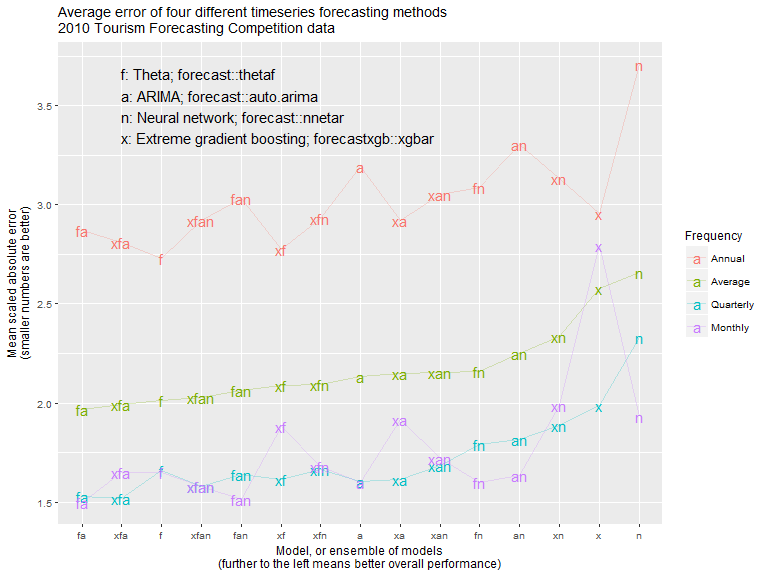

```r
leg <- "f: Theta; forecast::thetaf\na: ARIMA; forecast::auto.arima
n: Neural network; forecast::nnetar\nx: Extreme gradient boosting; forecastxgb::xgbar"

Tcomp_results %>%
  ggplot(aes(x = model, y =  MASE, colour = Frequency, label = model)) +
  geom_text(size = 4) +
  geom_line(aes(x = as.numeric(model)), alpha = 0.25) +
  scale_y_continuous("Mean scaled absolute error\n(smaller numbers are better)") +
  annotate("text", x = 2, y = 3.5, label = leg, hjust = 0) +
  ggtitle("Average error of four different timeseries forecasting methods\n2010 Tourism Forecasting Competition data") +
  labs(x = "Model, or ensemble of models\n(further to the left means better overall performance)") +
  theme_grey(9)
```

We see the overall best performing ensemble is the average of the Theta and ARIMA models - the two from the more traditional timeseries forecasting approach. The two machine learning methods (neural network and extreme gradient boosting) are not as effective, at least in these implementations. As individual methods, they are the two weakest, although the extreme gradient boosting method provided in `forecastxgb` performs noticeably better than `forecast::nnetar` for the annual and quarterly data.

Theta by itself is the best performing with the annual data - simple methods work well when the dataset is small and highly aggregate. The best that can be said of the `xgbar` approach in this context is that it doesn’t damage the Theta method much when included in a combination - several of the better performing ensembles have `xgbar` as one of their members. In contrast, the neural network models do badly with this collection of annual data.

Overall, I conclude that with univariate data, `xgbar` has little to add to an ensemble that already contains `auto.arima` and `thetaf` (or - not shown - the closely related `ets`). I believe however that inclusion of `xreg` external regressors would shift the balance in favour of `xgbar` and maybe even `nnetar` - the more complex and larger the dataset, the better the chance that these methods will have something to offer. If and when I find a large collection of timeseries competition data with external regressors I will probably add a second vignette, or at least a blog post at http://ellisp.github.io.